# Identifiability of topic model

Kushal K Dey

July 21, 2015

In this script, we try to check if the topic model we fit is indeed identifiable or not. The question arose because when we fitted k=2 clusters for the Whole Blood, it seemed to be forming two clusters, seemingly one representing RBC and one WBC from the gene annotations, but the proportions would vary from $0$ to $1$ for both the clusters, whereas we usually expect RBC and WBC to be present in the blood sample in the ratios of $40:60$ to $60:40$. We would like to check for a simulation design that if we simulate blood samples so that across the samples, the proportion of RBC changes on a continuous scale from $0.4$ to $0.6$ and the proportion of WBC correspondingly, changes from $0.6$ to $0.4$.

## Taddy model with k=2 (an example that works)

```r
library(maptpx)
n.out <- 200
omega_sim <- cbind(seq(0.6,0.4,length.out=n.out), 1- seq(0.6,0.4,length.out=n.out));
K <- dim(omega_sim)[2];
barplot(t(omega_sim),col=2:(K+1),axisnames=F,space=0,border=NA,main=paste("No. of clusters=",K),las=1,ylim=c(0,1),cex.axis=1.5,cex.main=1.4)
```

```r
freq <- rbind(c(0.1,0.2,rep(0.70/98,98)),c(rep(0.70/98,98), 0.1,0.2));
```

```r
counts <- t(do.call(cbind,lapply(1:dim(omega_sim)[1], function(x) rmultinom(1,1000,prob=omega_sim[x,]%*%freq))));
```

```r
Topic_clus <- topics(counts, K=2,tol=0.001);
```

[output not shown]

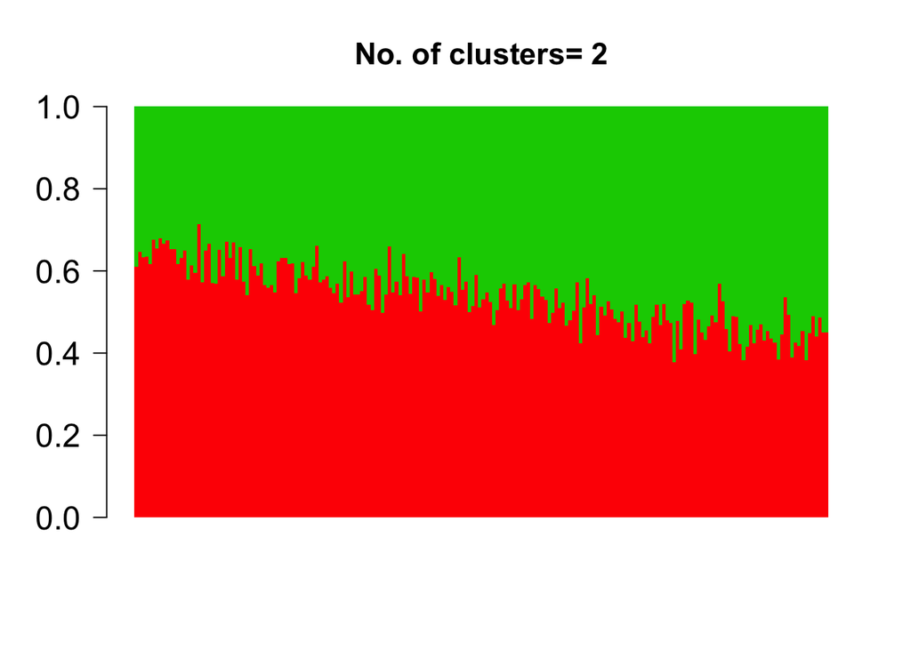

```r
K=2
barplot(t(Topic_clus$omega),col=2:(K+1),axisnames=F,space=0,border=NA,main=paste("No. of clusters=",K),las=1,ylim=c(0,1),cex.axis=1.5,cex.main=1.4)
```

## Taddy model with k=2 (an example that shows very high variation)

When we take 500 genes with 200 samples with 2 clusters such that the relative expression of the genes across the groups is kind of close, then the Structure does not seem to detect it very strongly as in the previous case.

```r
library(maptpx)
n.out <- 200
omega_sim <- cbind(seq(0.6,0.4,length.out=n.out), 1- seq(0.6,0.4,length.out=n.out));
K <- dim(omega_sim)[2];
barplot(t(omega_sim),col=2:(K+1),axisnames=F,space=0,border=NA,main=paste("No. of clusters=",K),las=1,ylim=c(0,1),cex.axis=1.5,cex.main=1.4)
```

```r
freq <- rbind(c(0.01,0.05,rep(0.70/498,498)),c(rep(0.70/498,498), 0.01,0.05));
```

```r
counts <- t(do.call(cbind,lapply(1:dim(omega_sim)[1], function(x) rmultinom(1,1000,prob=omega_sim[x,]%*%freq))));
```

```r
Topic_clus <- topics(counts, K=2,tol=0.001);
```

```
##
## Estimating on a 200 document collection.
## Fitting the 2 topic model.
## log posterior increase: 16.961, 12.505, 7.07, 4.736, 3.656, 2.984, 2.42, 1.894, 1.432, 1.07, 0.809, 0.627, 0.499, 0.405, 0.335, 0.279, 0.235, 0.199, 0.17, 0.146, 0.126, 0.109, done.
```

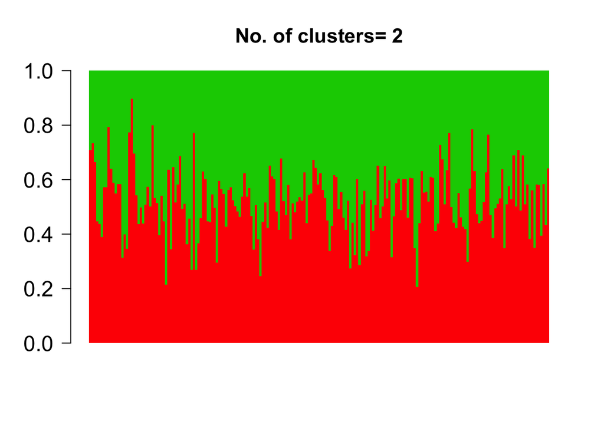

```r
K=2
barplot(t(Topic_clus$omega),col=2:(K+1),axisnames=F,space=0,border=NA,main=paste("No. of clusters=",K),las=1,ylim=c(0,1),cex.axis=1.5,cex.main=1.4)
```

Is there any significant change in patterns when actually there are more underlying clusters than just two clusters and we fit a k=2 model?

## Taddy model with actual k >2

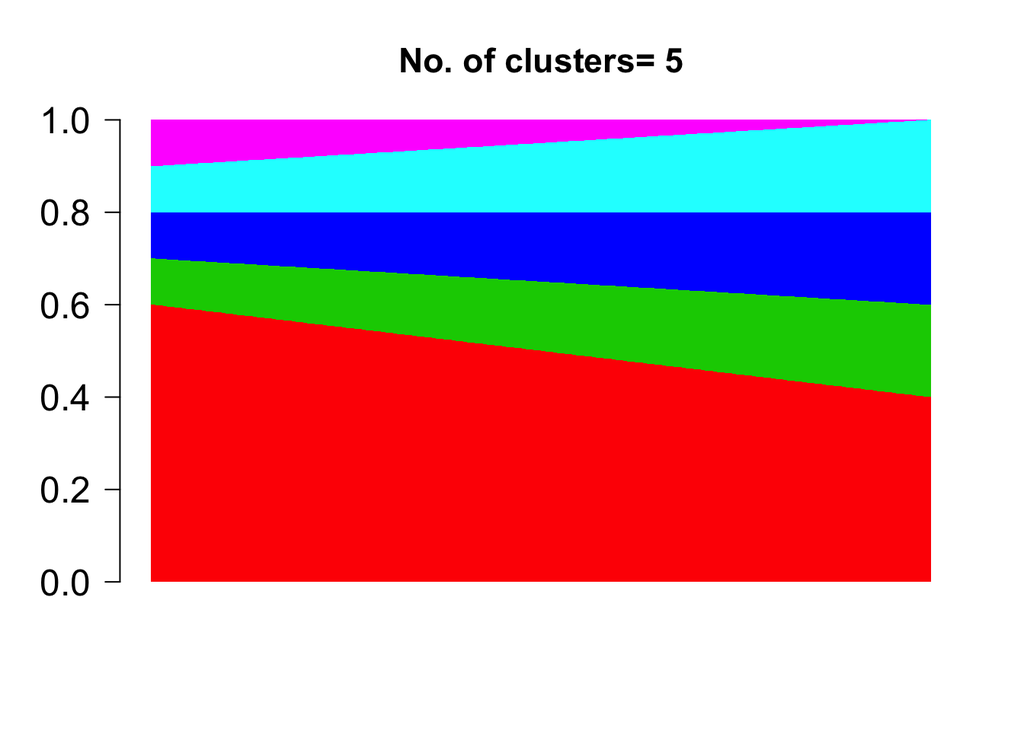

```r
library(maptpx)
n.out <- 200
omega_sim <- cbind(seq(0.6,0.4,length.out=n.out), seq(0.1,0.2,length.out=n.out),seq(0.1,0.2,length.out=n.out), seq(0.1,0.2,length.out=n.out), 1- seq(0.6,0.4,length.out=n.out)-seq(0.1,0.2,length.out=n.out)-seq(0.1,0.2,length.out=n.out)-seq(0.1,0.2,length.out=n.out));
K <- dim(omega_sim)[2];
barplot(t(omega_sim),col=2:(K+1),axisnames=F,space=0,border=NA,main=paste("No. of clusters=",K),las=1,ylim=c(0,1),cex.axis=1.5,cex.main=1.4)
```

The $F$ matrix of the proportional expression values is taken as follows

```r
freq <- rbind(c(0.01,0.02,rep(0.97/498,498)),c(rep(0.98/498,498),0.01,0.01),c(rep(0.97/498,498), 0.01,0.02),c(0.01,0.01,0.1,0.2,rep(0.68/496,496)),c(rep(0.05,10),0.02,rep(0.48/489,489)));
```

Then we generate a counts matrix for the given $L$ topic proportion matrix and $F$ expression matrix.

```r
counts <- t(do.call(cbind,lapply(1:dim(omega_sim)[1], function(x) rmultinom(1,1000,prob=omega_sim[x,]%*%freq))));
```

Next we fit a topic model on the counts matrix for $K=2$ and see whether we get back the same patterns as the true topic proportion matrix.

```r
Topic_clus <- topics(counts, K=2,tol=0.001);
```

```
##
## Estimating on a 200 document collection.
## Fitting the 2 topic model.
## log posterior increase: 19.366, 10.46, 8.468, 4.923, 3.104, 2.05, 1.346, 0.872, 0.564, 0.365, 0.224, 0.133, 0.08, done.
```

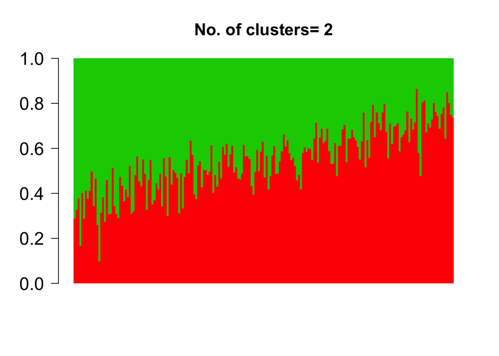

```r
K=2
barplot(t(Topic_clus$omega),col=2:(K+1),axisnames=F,space=0,border=NA,main=paste("No. of clusters=",K),las=1,ylim=c(0,1),cex.axis=1.5,cex.main=1.4)
```

We change the model slightly and instead of the multinomial model from which we simulated in the previous case, we now simulate from the Poisson identity and the Poisson log link models respectively.

# Poisson GLM or log link model

First we give an example of the Poisson GLM or log link model fr simulation and then we use Matt Taddy’s function to obtain the clustering.

```r
library(maptpx)
n.out <- 200
omega_sim <- cbind(seq(0.6,0.4,length.out=n.out), 1- seq(0.6,0.4,length.out=n.out));
K <- dim(omega_sim)[2];
barplot(t(omega_sim),col=2:(K+1),axisnames=F,space=0,border=NA,main=paste("No. of clusters=",K),las=1,ylim=c(0,1),cex.axis=1.5,cex.main=1.4)
```

```r
freq <- rbind(c(0.01,0.05,rep(0.94/498,498)),c(rep(0.94/498,498), 0.05,0.01));
```

```r
counts <- t(do.call(cbind,lapply(1:dim(omega_sim)[1], function(x) rpois(dim(freq)[2],exp(omega_sim[x,]%*%(freq+3))))));
```

```r
Topic_clus <- topics(counts, K=2,tol=0.001);
```

```
##
## Estimating on a 200 document collection.
## Fitting the 2 topic model.
## log posterior increase: 21.075, 9.276, 0.908, done.
```

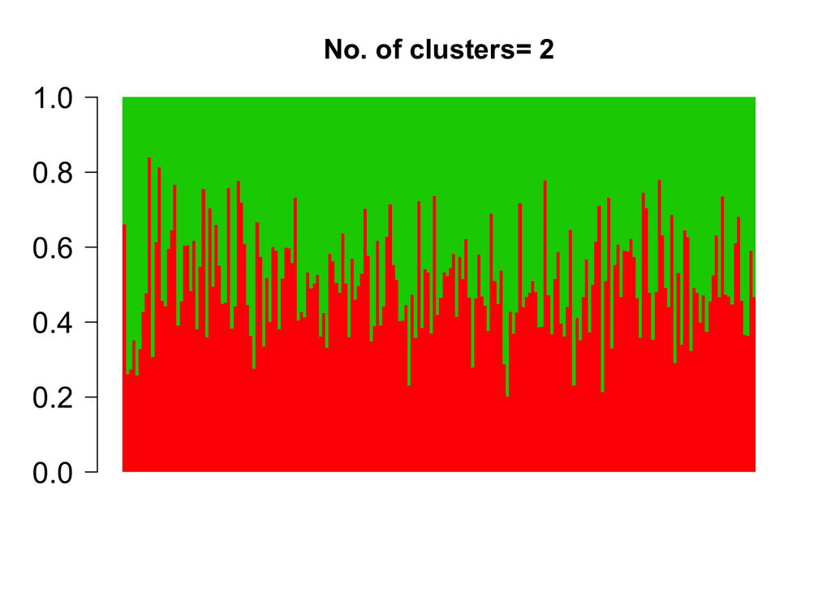

```r
K=2
barplot(t(Topic_clus$omega),col=2:(K+1),axisnames=F,space=0,border=NA,main=paste("No. of clusters=",K),las=1,ylim=c(0,1),cex.axis=1.5,cex.main=1.4)
```

# Poisson identity link model

```r
library(maptpx)
n.out <- 200
omega_sim <- cbind(seq(0.6,0.4,length.out=n.out), 1- seq(0.6,0.4,length.out=n.out));
K <- dim(omega_sim)[2];
barplot(t(omega_sim),col=2:(K+1),axisnames=F,space=0,border=NA,main=paste("No. of clusters=",K),las=1,ylim=c(0,1),cex.axis=1.5,cex.main=1.4)
```

```r
freq <- rbind(c(0.01,0.05,rep(0.94/498,498)),c(rep(0.94/498,498), 0.05,0.01));
```

```r
counts <- t(do.call(cbind,lapply(1:dim(omega_sim)[1], function(x) rpois(dim(freq)[2],omega_sim[x,]%*%exp(freq+3)))));
```

```r
Topic_clus <- topics(counts, K=2,tol=0.001);
```

```
##
## Estimating on a 200 document collection.
## Fitting the 2 topic model.
## log posterior increase: 59.569, 24.719, done.
```

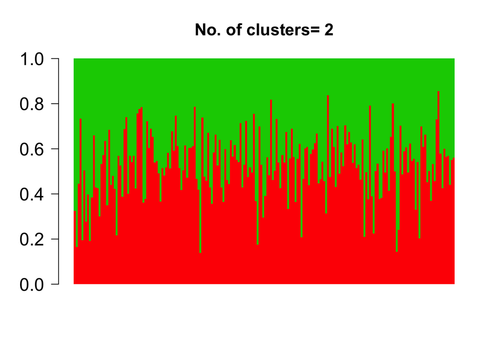

```r
K=2
barplot(t(Topic_clus$omega),col=2:(K+1),axisnames=F,space=0,border=NA,main=paste("No. of clusters=",K),las=1,ylim=c(0,1),cex.axis=1.5,cex.main=1.4)
```